# A View of Big Man ‘Care Factor’

Daniel Wolf

March 2nd, 2017

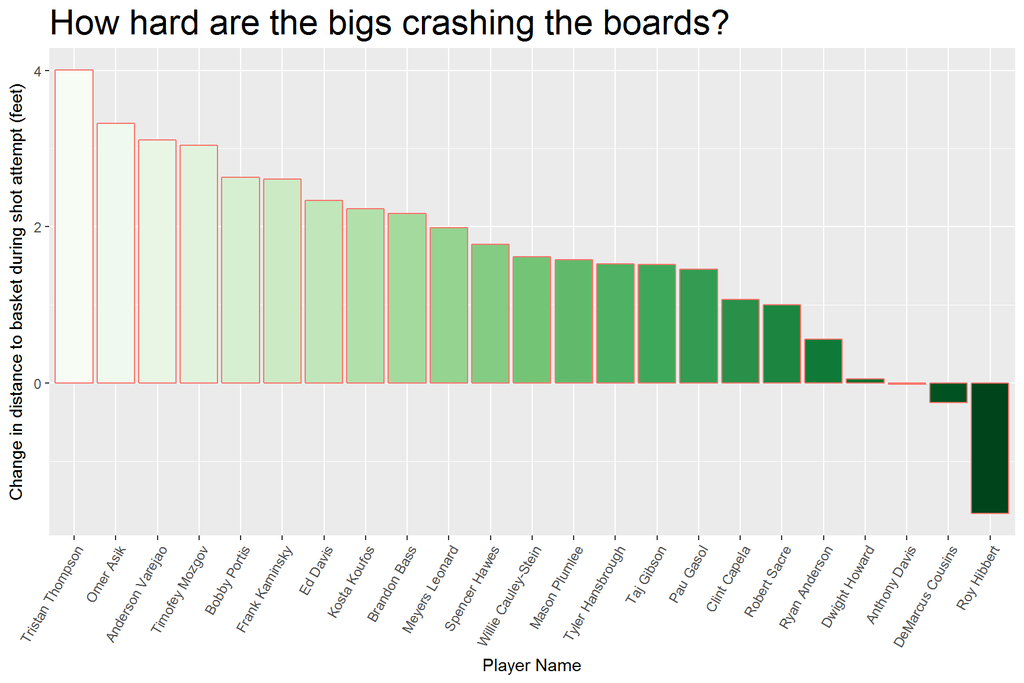

#### Approach

- Measured each big man’s **change in their distance to the basket** while the ball is in the air during a shot attempt
- All scenarios where they started between 10 to 20 feet from the basket. There are 1,231 samples across 23 big men for these 5 games.
- Regardless of whether they actually get the rebound. This metric is based on effort as opposed to skill.

#### Key Takeaways

- On average, Tristan Thompson gets 4 feet closer to the basket while the ball is in the air!
- DeMarcus Cousins and Roy Hibbert get further from the basket in the same scenarios

#### About

I created this plot during the ESPN Hackathon at the 2017 Sloan Sports Analytics Conference. The Hackathon prompt was to “Measure the Immeasurable”, so I attempted to quantify how much effort the big men are putting into their rebounding. The data source is SportVU player tracking from 5 full NBA games in the 2015-16 season. For R code used to calculate and visualize, you can visit http://github.com/dwolfATL/Sports-Analytics.